# Has the inital age of people starting their careers in the Korean Music decrased over time?

A common observation among fans of Korean pop music is that the the musicians, also refered to as “idols”, are being “debuted” or beginning their music career younger than ever before. We can find the average age of the kpop idols through knowing the birthdays of these idols over decades.

Data set taken from https://www.kaggle.com/datasets/onlyrohit/all-kpop-idols.

# Packages

```r
library(tidyverse)
library(tidyr)
library(janitor)
library(here)
library(dplyr)
library(lubridate)
```

# Import Data

```r
thisfile <- here("data", "kpopidolsv3_updated.csv")

rawdata <- read.csv(thisfile) |> clean_names()
```

For the sake of our analysis, we will temporarily remove the columns, korean_name, K_stage_name, height, weight, birthplace, and instagram for relevance sake. We will name this data frame df_ages, because we will do analysis regarding the kpop idol’s age with this data frame.

```r
df_ages <- rawdata |>

  select(full_name, date_of_birth, group, debut, gender)
```

```r
df_ages1 <- df_ages |>
  mutate(date_of_birth = as.Date(date_of_birth, tryFormats = c("%d/%m/%Y"))) |>
  mutate(date_of_birth = ymd(date_of_birth))|>
  mutate(debut = as.Date(debut, tryFormats = c("%d/%m/%Y"))) |>
  mutate(debut = ymd(debut)) |>
  drop_na(debut | date_of_birth) |>
  subset(debut > date_of_birth) |>
  mutate(debut_age_years = time_length(difftime(debut, date_of_birth), "years")) |>
  mutate(debut_decade = floor(as.numeric(debut-as.Date("2000/01/01"))/365/10)*10)
```

# Plot of Debut to Age (in Years)

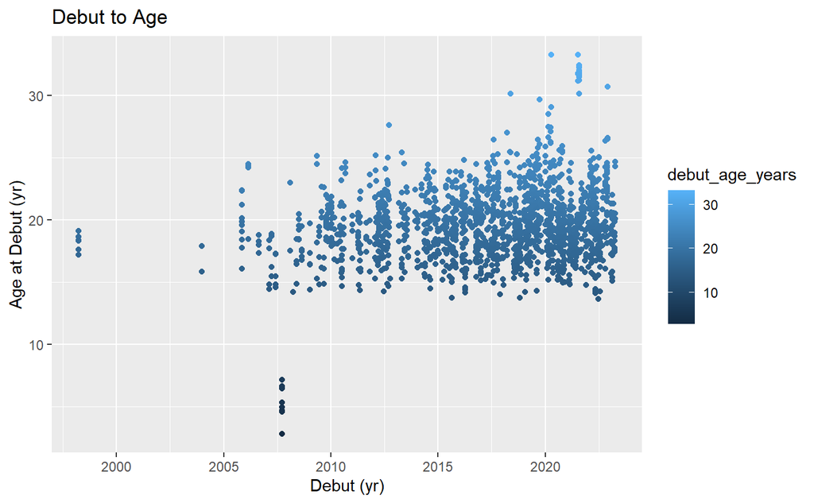

```r
ggplot(df_ages1, aes(debut, debut_age_years)) + geom_point(aes(color = debut_age_years))  + labs( x = "Debut (yr)", y =  "Age at Debut (yr)", title = "Debut to Age" )
```

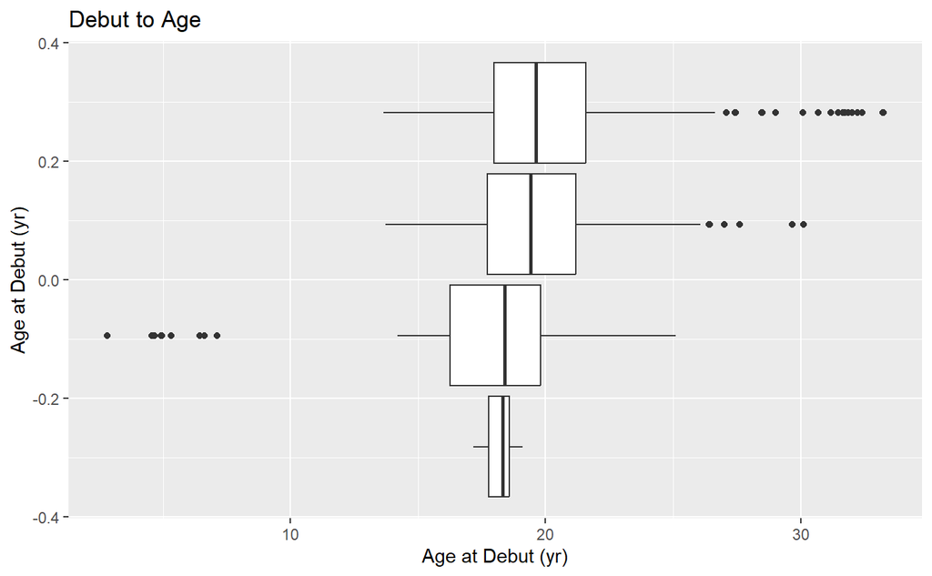

```r
ggplot(df_ages1, aes(debut_age_years,group=debut_decade)) +geom_boxplot() + labs( x = "Age at Debut (yr)", y =  "Age at Debut (yr)", title = "Debut to Age" )
```

```r
debut1900s <- df_ages1 |>
  filter(debut_decade %in% -10)

debut2000 <- df_ages1 |>
  filter(debut_decade %in% 0)


debut2010 <- df_ages1 |>
  filter(debut_decade %in% 10)


debut2020 <- df_ages1 |>
  filter(debut_decade %in% 20)
```

```r
print("1900:")
```

```
[1] "1900:"
```

```r
summary(debut1900s$debut_age_years)
```

```
   Min. 1st Qu.  Median    Mean 3rd Qu.    Max.
  17.17   17.78   18.33   18.20   18.58   19.10
```

```r
print("2000:")
```

```
[1] "2000:"
```

```r
summary(debut2000$debut_age_years)
```

```
   Min. 1st Qu.  Median    Mean 3rd Qu.    Max.
  2.812  16.258  18.386  17.524  19.808  25.117
```

```r
print("2010:")
```

```
[1] "2010:"
```

```r
summary(debut2010$debut_age_years)
```

```
   Min. 1st Qu.  Median    Mean 3rd Qu.    Max.
  13.72   17.71   19.42   19.55   21.19   30.12
```

```r
print("2020:")
```

```
[1] "2020:"
```

```r
summary(debut2020$debut_age_years)
```

```
   Min. 1st Qu.  Median    Mean 3rd Qu.    Max.
  13.63   17.98   19.62   20.13   21.59   33.24
```

From the data, it seems like the average age has actually increased. A limitation of this data set is that it is biased towards the mid-2000’s to the present. This means that there would have to be more data collected on the K-Pop groups’ first musical released from the 1900’s to mid-2000s. Another explanation for this data is that, perhaps as time went on, there were more K-Pop idols and K-pop idol groups debuting, and with this increased volumn, there were more idols both much older than usual and much younger than usual.

Since the data set itself was not recorded in the exact way that is necessary for this analysis, some changes to the data set were needed.

# Do Males or Females tend to debut earlier than each other?

```r
df_ages1 |>
  group_by(gender) |>
  summarise(average_age = mean(debut_age_years))
```

| gender | average_age |
| --- | --- |
| F | 19.52774 |
| M | 19.69721 |

From this result, it seems like there is little variation between the males and females at the age they debut.

# Which company debuts the oldest idols? Which company debuts the youngest idol?

First, create the data frame

```r
df_company <- rawdata |>

  select(full_name, date_of_birth, group, debut, gender, company) |>
  mutate(date_of_birth = as.Date(date_of_birth, tryFormats = c("%d/%m/%Y"))) |>
  mutate(date_of_birth = ymd(date_of_birth))|>
  mutate(debut = as.Date(debut, tryFormats = c("%d/%m/%Y"))) |>
  mutate(debut = ymd(debut)) |>
  drop_na(debut | date_of_birth) |>
  subset(debut > date_of_birth) |>
  mutate(debut_age_years = time_length(difftime(debut, date_of_birth), "years")) |>
  mutate(debut_decade = floor(as.numeric(debut-as.Date("2000/01/01"))/365/10)*10)
```

Then,

```r
df_company |>
  group_by(company) |>
  summarise(average_age = mean(debut_age_years)) |>
  arrange(desc(average_age))
```

| company | average_age |
| --- | --- |
| Winnerzone | 31.96783 |
| Good Luck | 31.61602 |
| ARA-LINE | 31.13347 |
| Nature Space | 27.90509 |
| CHITWN | 26.79425 |
| KD | 25.90897 |
| Kyun Create | 24.66530 |
| J-Star | 24.64644 |
| C-JeS | 24.17614 |
| DR | 24.08008 |

[output cut: 168 more lines]

Updates to the original data set. * Took out group GIDONDAE because they never became an actual group. * Changed all of KARD’s debut date from Sept. 3rd, 2007 to July 29. 2017 * Change Lee Junyoung from U-Kiss’s debut date year from 2008 to July, 2014 * Changed HOT ISSUES’ debut date from May 17, 2017 to April 28th, 2021 * Deleted Yoon Jia from Midas Company * Change TVXQ’s debut date * Chaged Gate9’s debut date * Changed Girl’s World debute date